# Final Project Visualisasi Informasi

Muhammad Wildan Maulidani - 05211640000029

> Dataset : Suicide Rates Overview 1985 to 2016 (Compares socio-economic info with suicide rates by year and country)  
> Penjelasan : Dataset Suicide Rates Overview 1985 to 2016 merupakan dataset yang dikompilasi dari empat kumpulan data yaitu :  
> 1. United Nations Development Program. (2018). Human development index (HDI).  
> 2. World Bank. (2018). World development indicators: GDP (current US) by country:1985 to 2016.  
> 3. [Szamil]. (2017). Suicide in the Twenty-First Century [dataset].  
> 4. World Health Organization. (2018). Suicide prevention.  
> Keempat data ini dihubungkan oleh waktu dan tempat, dan dibangun menjadi dataset ini untuk menemukan hubungan antara social-ekonomi dengan peningkatan tingkat bunuh diri pada negara-negara di dunia. Dataset ini terinspirasi dari pencegahan dan penanganan untuk bunuh diri. Dataset ini dapat diambil dari link https://www.kaggle.com/russellyates88/suicide-rates-overview-1985-to-2016.  
> Source code pada jupyter notebook untuk dan Laporan final FP ini dapat didownload pada https://github.com/maulidaniw/Suicide-vis

# Import Libraries

```python
import numpy as np
import pandas as pd
import matplotlib.pyplot as plt
import seaborn as sns
sns.set(style="whitegrid")
pd.set_option('mode.chained_assignment', None)
```

# Overview Data

#### Deskripsi Kolom

> **country** : Nama Negara  
> **year** : Tahun  
> **sex** : Jenis kelamin  
> **age** : Rentang usia  
> **suicides_no** : Jumlah suicide untuk negara, tahun, jenis kelamin, dan rentang usia tertentu  
> **population** : Jumlah populasi untuk negara, tahun, jenis kelamin, dan rentang usia tertentu  
> **suicides/100k** : Ratio nilai suicide dengan 100k populasi  
> **country-year** : Gabungan negara dengan tahun  
> **HDI for year** : Human Development Index Negara  
> **gdp_for_year** : Nilai GDP satu tahun untuk negara  
> **gdp_per_capita** : Nilai GDP per capita untuk negara  
> **generation** : Rentang Generasi

```python
data = pd.read_csv('data.csv')
data
```

|  | country | year | sex | age | suicides_no | population | suicides/100k pop | country-year | HDI for year | gdp_for_year ($) | gdp_per_capita ($) | generation |
| --- | --- | --- | --- | --- | --- | --- | --- | --- | --- | --- | --- | --- |
| 0 | Albania | 1987 | male | 15-24 years | 21 | 312900 | 6.71 | Albania1987 | NaN | 2,156,624,900 | 796 | Generation X |
| 1 | Albania | 1987 | male | 35-54 years | 16 | 308000 | 5.19 | Albania1987 | NaN | 2,156,624,900 | 796 | Silent |
| 2 | Albania | 1987 | female | 15-24 years | 14 | 289700 | 4.83 | Albania1987 | NaN | 2,156,624,900 | 796 | Generation X |
| 3 | Albania | 1987 | male | 75+ years | 1 | 21800 | 4.59 | Albania1987 | NaN | 2,156,624,900 | 796 | G.I. Generation |
| 4 | Albania | 1987 | male | 25-34 years | 9 | 274300 | 3.28 | Albania1987 | NaN | 2,156,624,900 | 796 | Boomers |
| ... | ... | ... | ... | ... | ... | ... | ... | ... | ... | ... | ... | ... |
| 27815 | Uzbekistan | 2014 | female | 35-54 years | 107 | 3620833 | 2.96 | Uzbekistan2014 | 0.675 | 63,067,077,179 | 2309 | Generation X |
| 27816 | Uzbekistan | 2014 | female | 75+ years | 9 | 348465 | 2.58 | Uzbekistan2014 | 0.675 | 63,067,077,179 | 2309 | Silent |
| 27817 | Uzbekistan | 2014 | male | 5-14 years | 60 | 2762158 | 2.17 | Uzbekistan2014 | 0.675 | 63,067,077,179 | 2309 | Generation Z |
| 27818 | Uzbekistan | 2014 | female | 5-14 years | 44 | 2631600 | 1.67 | Uzbekistan2014 | 0.675 | 63,067,077,179 | 2309 | Generation Z |
| 27819 | Uzbekistan | 2014 | female | 55-74 years | 21 | 1438935 | 1.46 | Uzbekistan2014 | 0.675 | 63,067,077,179 | 2309 | Boomers |

27820 rows × 12 columns

```python
print("Dataset berisi {} baris and {} kolom".format(data.shape[0], data.shape[1]))
```

```
Dataset berisi 27820 baris and 12 kolom
```

# Praproses Data

1. Mengubah Nama Kolom

```python
data.columns = ['country', 'year', 'sex', 'age', 'suicides_no', 'population',
       'suicides_per_100k', 'country_year', 'HDI_for_year',
       'gdp_for_year', 'gdp_per_capita', 'generation']
```

2. Cek Missing Value

```python
data.isnull().sum()
```

```
country                  0
year                     0
sex                      0
age                      0
suicides_no              0
population               0
suicides_per_100k        0
country_year             0
HDI_for_year         19456
gdp_for_year             0
gdp_per_capita           0
generation               0
dtype: int64
```

Data hanya memiliki missing value pada kolom **HDI_for_year**, dan missing value yang ada tidak akan diisi dengan data lain atau dihapus karena kolom tersebut tidak akan digunakan untuk melakukan visualisasi informasi

3. Mengelompokkan data berdasarkan tahun tertentu dan jenis kelamin, dan menghitung suicides rate nya

```python
def suicides_rate_year_sex(data, year):
    #Filter data sesuai tahun
    data_year = data[data['year'] == year]

    data_suicide_rate = data_year.groupby(['country'])['suicides_no','population'].sum().reset_index()
    data_suicide_rate['suicide_rate'] = data_suicide_rate['suicides_no']/data_suicide_rate['population']
    data_male = data_year[data_year['sex']=='male'].groupby(['country','sex'])['suicides_no'].sum().reset_index()
    data_male = data_male.drop(['sex'],axis = 1)
    data_male.columns = ['country','suicides_no_male']
    data_join = pd.merge(data_suicide_rate, data_male, on='country')

    data_join['suicides_no_female'] = data_join['suicides_no'] - data_join['suicides_no_male']
    data_join['suicide_rate_male'] = data_join['suicides_no_male']/data_join['population']
    data_join['suicide_rate_female'] = data_join['suicides_no_female']/data_join['population']

    return data_join

data_2014 = suicides_rate_year_sex(data, 2014)
data_2014
```

|  | country | suicides_no | population | suicide_rate | suicides_no_male | suicides_no_female | suicide_rate_male | suicide_rate_female |
| --- | --- | --- | --- | --- | --- | --- | --- | --- |
| 0 | Antigua and Barbuda | 0 | 90837 | 0.000000 | 0 | 0 | 0.000000 | 0.000000 |
| 1 | Argentina | 3231 | 39276555 | 0.000082 | 2544 | 687 | 0.000065 | 0.000017 |
| 2 | Armenia | 58 | 2803029 | 0.000021 | 43 | 15 | 0.000015 | 0.000005 |
| 3 | Australia | 2891 | 21927587 | 0.000132 | 2182 | 709 | 0.000100 | 0.000032 |
| 4 | Austria | 1314 | 8141165 | 0.000161 | 990 | 324 | 0.000122 | 0.000040 |
| ... | ... | ... | ... | ... | ... | ... | ... | ... |
| 73 | Ukraine | 7968 | 40464165 | 0.000197 | 6412 | 1556 | 0.000158 | 0.000038 |
| 74 | United Kingdom | 4788 | 60570482 | 0.000079 | 3717 | 1071 | 0.000061 | 0.000018 |
| 75 | United States | 42769 | 297749735 | 0.000144 | 33110 | 9659 | 0.000111 | 0.000032 |
| 76 | Uruguay | 591 | 3177645 | 0.000186 | 460 | 131 | 0.000145 | 0.000041 |
| 77 | Uzbekistan | 2095 | 27313507 | 0.000077 | 1405 | 690 | 0.000051 | 0.000025 |

78 rows × 8 columns

4. Mengelompokkan data berdasarkan tahun dan menghitung suicides rate nya

```python
def suicide_all_year(data):
    data_all_year = data.groupby(['country','year'])['suicides_no','population'].sum().reset_index()
    data_all_year['suicide_rate'] = data_all_year['suicides_no']/ data_all_year['population']
    return data_all_year

data_all_year = suicide_all_year(data)
data_all_year
```

|  | country | year | suicides_no | population | suicide_rate |
| --- | --- | --- | --- | --- | --- |
| 0 | Albania | 1987 | 73 | 2709600 | 0.000027 |
| 1 | Albania | 1988 | 63 | 2764300 | 0.000023 |
| 2 | Albania | 1989 | 68 | 2803100 | 0.000024 |
| 3 | Albania | 1992 | 47 | 2822500 | 0.000017 |
| 4 | Albania | 1993 | 73 | 2807300 | 0.000026 |
| ... | ... | ... | ... | ... | ... |
| 2316 | Uzbekistan | 2010 | 1464 | 25651783 | 0.000057 |
| 2317 | Uzbekistan | 2011 | 1640 | 25978049 | 0.000063 |
| 2318 | Uzbekistan | 2012 | 1835 | 26381830 | 0.000070 |
| 2319 | Uzbekistan | 2013 | 1950 | 26838924 | 0.000073 |
| 2320 | Uzbekistan | 2014 | 2095 | 27313507 | 0.000077 |

2321 rows × 5 columns

5. Mengelompokkan data berdasarkan kelompok umur dan negara

```python
def suicide_all_age(data):
    data_age = data.groupby(['age']).suicides_no.sum().reset_index()
    return data_age

def suicide_year_age(data, year):
    data_age = data[data['year']==year]
    data_age = data_age.groupby(['age']).suicides_no.sum().reset_index()
    return data_age

def suicide_year_age_country(data, year,country):
    data_age = data[(data['year']==year) & (data['country']==country)]
    data_age = data_age.groupby(['age']).suicides_no.sum().reset_index()
    return data_age

data_2015_age_us = suicide_year_age_country(data,2015,'United States')
data_2015_age_us
```

|  | age | suicides_no |
| --- | --- | --- |
| 0 | 15-24 years | 5491 |
| 1 | 25-34 years | 6947 |
| 2 | 35-54 years | 15687 |
| 3 | 5-14 years | 413 |
| 4 | 55-74 years | 11940 |
| 5 | 75+ years | 3711 |

6. Menggabungkan data suicide rate dengan GDP Negara

```python
def suicide_gdp(data):
    data_suicide_gdp = data.groupby(['country','year','gdp_per_capita'])['suicides_no','population'].sum().reset_index()
    data_suicide_gdp['suicide_rate'] = data_suicide_gdp['suicides_no']/ data_suicide_gdp['population']
    return data_suicide_gdp

data_suicide_gdp = suicide_gdp(data)
data_suicide_gdp
```

|  | country | year | gdp_per_capita | suicides_no | population | suicide_rate |
| --- | --- | --- | --- | --- | --- | --- |
| 0 | Albania | 1987 | 796 | 73 | 2709600 | 0.000027 |
| 1 | Albania | 1988 | 769 | 63 | 2764300 | 0.000023 |
| 2 | Albania | 1989 | 833 | 68 | 2803100 | 0.000024 |
| 3 | Albania | 1992 | 251 | 47 | 2822500 | 0.000017 |
| 4 | Albania | 1993 | 437 | 73 | 2807300 | 0.000026 |
| ... | ... | ... | ... | ... | ... | ... |
| 2316 | Uzbekistan | 2010 | 1533 | 1464 | 25651783 | 0.000057 |
| 2317 | Uzbekistan | 2011 | 1767 | 1640 | 25978049 | 0.000063 |
| 2318 | Uzbekistan | 2012 | 1964 | 1835 | 26381830 | 0.000070 |
| 2319 | Uzbekistan | 2013 | 2150 | 1950 | 26838924 | 0.000073 |
| 2320 | Uzbekistan | 2014 | 2309 | 2095 | 27313507 | 0.000077 |

2321 rows × 6 columns

# Visualisasi 1 - Negara dengan Suicide Rate paling tinggi pada tahun tertentu

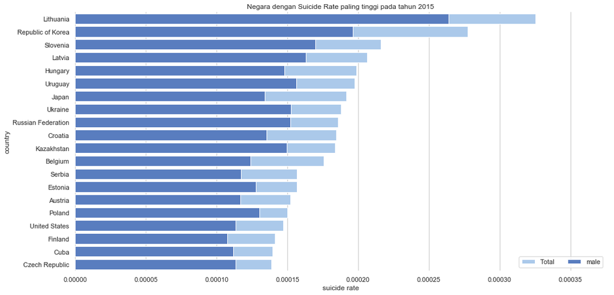

```python
def top_country_suicide_rates(years, top):
    # Initialize the matplotlib figure
    f, ax = plt.subplots(figsize=(16, 8))

    # Load the example car crash dataset
    year = years
    data_year = suicides_rate_year_sex(data, year)
    suicide = data_year.sort_values("suicide_rate", ascending=False)[:top]
    suicide_rate_max = data_year.suicide_rate.max()
    # Plot the total crashes
    sns.set_color_codes("pastel")
    sns.barplot(x="suicide_rate", y="country", data=suicide, label="Total", color="b")

    # Plot the crashes where alcohol was involved
    sns.set_color_codes("muted")
    sns.barplot(x="suicide_rate_male", y="country", data=suicide,label="male", color="b")

    # Add a legend and informative axis label
    ax.legend(ncol=2, loc="lower right", frameon=True)
    ax.set(xlim=(0, suicide_rate_max+0.00005), xlabel = 'suicide rate')
    ax.set_title("Negara dengan Suicide Rate paling tinggi pada tahun " +str(year))
    sns.despine(left=True, bottom=True)

top_country_suicide_rates(2015, 20)
```

> **Visualisasi : Bar Chart**  
> **Alasan**  
> Bar Chart digunakan karena dapat menampilkan perbandingan nilai-nilai setiap negara dan sehingga dapat dilihat negara mana yang memiliki nilai suicide rate paling tinggi. Selain itu dengan menggunakan bar chart, variable lain dapat dimasukkan seperti jenis kelamin sehingga dapat dilihat proporsi jenis kelamin pada setiap negara terhadap nilai suicide.  
> **Penjelasan**  
> Visualisasi bagian ini menggunakan grafik berupa diagram batang yang dapat membandingkan nilai suicide rate antara jenis kelamin pria dan seluruh jenis kelamin pada tiap negara. Pada visualisasi ini akan berhubungan dengan kolom country ,sex dan suicide_no. Barchart ini menggunakan visualisasi dengan menggunakan posisi horizontal pada valuenya dan pengelompokkannya secara vertical. Untuk penggunaan warna menggunakan pewarnaan Hue dimana dengan menggunakan metode pewarnaan ini maka akan dengan mudah ditangkap oleh orang yang melihat.  
> **Properties of Data**  
> Properti data yang digunakan dalam bar chart ini merupakan quantitative dimana grafik menggunakan data suicide_no, sex dan country.  
> **Properties of Image**  
> Grafik ini menggunakan bentuk batang dalam 2 dimensi, dimana besar batang dari masing-masing negara ditentukan berdasarkan nilai suicide rate tiap negara. Dan pewarnaan pada batang menunjukkan nilai suicide rate untuk jenis kelamin pria dan seluruh jenis kelamin  
> **Visual Encoding**  
> **What** : Visualisasi ini menunjukkan negara dengan suicide rate paling tinggi serta pengaruh jenis kelamin pada nilai suicide rate pada negara tersebut.  
> **Why** : Nilai Suicide Rate yang tinggi menunjukkan jumlah kejadian bunuh diri yang tinggi jika dibandingkan dengan populasi pada suatu negara  
> **Who** : Target Visualisasi ini adalah masyarakat dan organisasi kesehatan, dan negara  
> **How** : Yang pertama dilakukan adalah menghitung suicide rate untuk seluruh negara dengan membagi suicides_no terhadap populasi. Kemudian dilakukan filter untuk mengambil Top X Country dengan Suicide terting¬gi. Setelah itu dilakukan pembuatan bar plot dengan X = Suicide rate dan Y = Country. Kemudian dilakukan lagi pembuatan bar plot dengan X = Suicide rate male dan Y = Country, sehingga akan terdapat perbedaan warna terhadap nilai suicide rate male dan suicide rate pada bar plot tersebut.  
> **Analisis**  
> Pada visualisasi yang telah dilakukan kita dapat melihat 20 Negara dengan Suicide Rate paling tinggi pada tahun 2015, dimana 5 negara dengan nilai suicide rate paling tinngi yaitu Lithuania, Korea, Slovenia, Latvia dan Hungary. Dimana nilai Suicide rate pada negara Lithuania yaitu > 0.0003. Dapat dilihat juga bahwa negara-negara yang memiliki suicide rate paling tinngi bearda pada benua Eropa. Selain itu jika diketahui bahwa dari jumlah suicide pada jenis kelamin pria menyumbang sekitar 80% dari kesuluruhan suicide rate.

# Visualisasi 2 - Perkembangan jumlah Suicide pada tiap negara dari tahun ke tahun

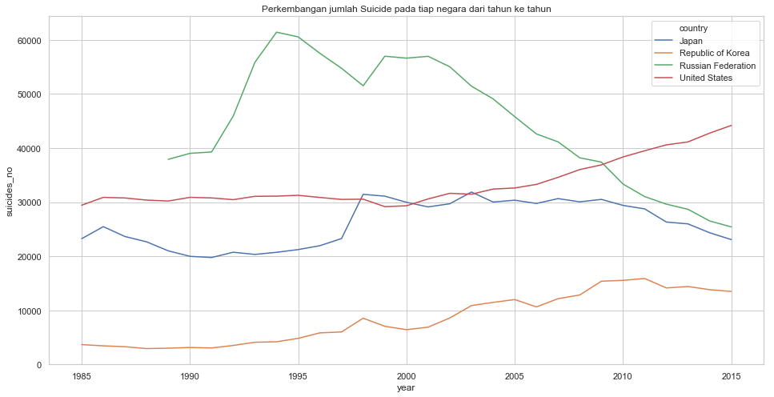

```python
def suicide_line_plot(country):
    data_suicade_high = data_all_year[data_all_year.country.isin(country)]
    fig, ax = plt.subplots(figsize=(16,8))
    sns.lineplot(data=data_suicade_high[['country','year','suicides_no']],x='year', y='suicides_no',hue='country', ax=ax)
    ax.set(title="Perkembangan jumlah Suicide pada tiap negara dari tahun ke tahun")

suicide_line_plot(['United States', 'Russian Federation','Japan','Republic of Korea'])
```

# Visualisasi 3 - Perbandingan kelompok Umur pada tiap negara terkait jumlah Suicide pada tiap negara

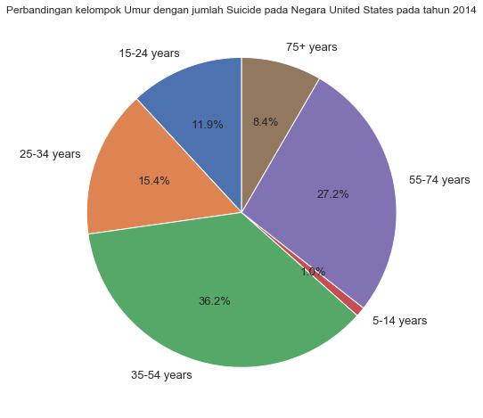

```python
def pie_country_year(year, country):
    data_pie = suicide_year_age_country(data,year,country)
    fig, ax1 = plt.subplots(figsize=(16,8))
    data_pie.plot(kind='pie', y = 'suicides_no', ax=ax1, autopct='%1.1f%%',
                  startangle=90, labels=data_pie['age'],legend = False, fontsize=13,
                  title=
                  "Perbandingan kelompok Umur dengan jumlah Suicide pada Negara " + str(country) +' pada tahun '+str(year))
    ax1.set_ylabel('')

pie_country_year(2014, 'United States')
```

> **Visualisasi : Pie Chart**  
> **Alasan**  
> Pie Chart untuk menampilkan perbandingan persentase dari variable seperti perbandingan presentase suicide tiap kelompok umur pada suatu negara.  
> **Penjelasan**  
> Visualisasi ini akan menggunakan bentuk pie dengan menampilkan persentase dari nilai suicide untuk masing-masing kelompok umur pada suatu negara.  
> **Properties of Data**  
> Properti data yang digunakan dalam pie chart ini merupakan quantitative dimana grafik menggunakan data suicide_no dan age.  
> **Properties of Image**  
> Grafik ini menggunakan bentuk lingkaran dalam 2 dimensi, dimana posisi dari masing-masing kelompok umur ditentukan berdasarkan luas bagian lingkaran dari masing-masing kelompok umur serta warna (color intensity) dari masing-masing bagian lingkaran tersebut.  
> **Visual Encoding**  
> **What** : Visualisasi ini menunjukkan presentase untuk setiap kelompok Umur terkait jumlah Suicide pada negara dan tahun tertentu  
> **Why** : Presentase dari setiap kelompok umur dapat menunjukkan kelompok umur mana yang memiliki jumlah kejadian suicide tertinggi  
> **Who** : Target Visualisasi ini adalah masyarakat dan organisasi kesehatan, dan negara  
> **How** : Yang pertama dilakukan adalah melakukan filter data berdasarkan tahun dan negara. Kemudian mengelompokkan data berdasarkan kelompok umur, dan mengambil nilai suicide untuk setiap kelompok umur. Setelah itu dilakukan pembuatan pie plot dengan Y = Suicide_no.  
> **Analisis**  
> Pada visualisasi yang telah dilakukan kita dapat melihat Perbandingan kelompok Umur terkait jumlah Suicide pada negara United States pada tahun 2014. Dapat dilihat bahwa kelompok umur 35-54 tahun memiliki presentasi tertingi yaitu 36.2% diikuti oleh kelompok umur 55-74, 25-34, 15-24, 75+ dan yang terakhir dengan presentase 1.0% yaitu kelompok umur 5-14 tahun. Dapat dilihat bahwa rentang umur dewasa yang memiliki jumlah suicide tertinggi.

# Visualisasi 4 - Hubungan antara nilai ekonomi(GDP) negara dengan Suicide rate pada tiap negara

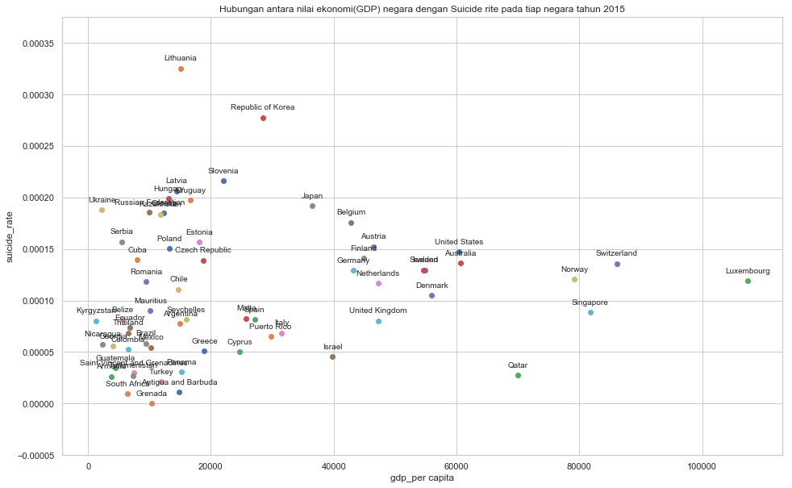

```python
def scat_gdp_suicide(year):
    fig= plt.figure(figsize=(16,10))

    data_year = data_suicide_gdp[data_suicide_gdp['year']==year].reset_index()
    X = data_year['gdp_per_capita']
    Y = data_year['suicide_rate']
    label = data_year['country']

    for i,j in enumerate(X):
        # look for the color based on vocabulary, if not found in vocubulary, then black is returned.
        plt.scatter(X[i] , Y[i])
        plt.annotate(label[i], # this is the text
                     (X[i],Y[i]), # this is the point to label
                     textcoords="offset points", # how to position the text
                     xytext=(0,10), # distance from text to points (x,y)
                     ha='center')
    plt.xlabel("gdp_per capita")
    plt.ylabel("suicide_rate")
    plt.title("Hubungan antara nilai ekonomi(GDP) negara dengan Suicide rite pada tiap negara tahun " +str(year))
    plt.ylim(data_year.suicide_rate.min()-0.00005, data_year.suicide_rate.max()+0.00005)
    plt.show()

scat_gdp_suicide(2015)
```

> **Visualisasi Scatter Plot**  
> **Alasan**  
> Scatter Plot digunakan untuk menampilkan hubungan antar dua variable seperti GDP terhadap nilai suicide rate pada tiap negara.  
> **Penjelasan**  
> Visualisasi ini akan merepresentasikan titik sebagai suatu negara dan diletakkan pada sumbu horizontal dan vertical berdasarkan nilai GDP dan suicide ratenya.  
> **Properties of Data**  
> Properti data yang digunakan dalam scatter plot ini merupakan quantitative dimana plot menggunakan data suicide_rate, gdp_per_capita dan country.  
> **Properties of Image**  
> Plot ini menggunakan bentuk titik yang merepresentasikan masing-masing negara berdasarkan nilai suicide rate dan gdp nya.  
> **Visual Encoding**  
> **What** : Visualisasi ini menunjukkan sebaran tiap negara berdasarkan nilai ekonomi(GDP) negara dan suicide rate nya.  
> **Why** : Sebaran dalam visualisasi ini dapat mencerminkan pola hubungan dari ekonomi(GDP) dan suicide rate pada negara berpengaruh atau tidak.  
> **Who** : Target Visualisasi ini adalah masyarakat dan organisasi kesehatan, dan negara  
> **How** : Yang pertama dilakukan adalah melakukan pengelompokkan berdasarkan negara dan tahun kemudian menghitung suicide rate untuk seluruh negara dengan membagi suicides_no terhadap populasi. Kemudian dilakukan filter untuk mengambil tahun tertentu. Setelah itu dilakukan pembuatan scatter plot dengan X = gdp_per_capita dan Y = suicide_rate. Dan melakukan pelabelan nama negara untuk setiap titiknya.  
> **Analisis**  
> Pada visualisasi yang telah dilakukan kita dapat melihat hubungan antara nilai ekonomi(GDP) negara dengan nilai Suicide rate pada tiap negara pada tahun 2015. Dimana dapat disimpulkan tidak terdapat hubungan anatara kedua atribut tersebut, Lithuania debagai negara dengan suicide rate tertingi memiliki gdp per capita yang hampir sama dengan negara dengan suicide rate terkecil seperti Grenada, South Africa dan Antigua and Barbuda.

# Visualisasi 5 - Jumlah Kumulatif Suicide per tahun tiap negara

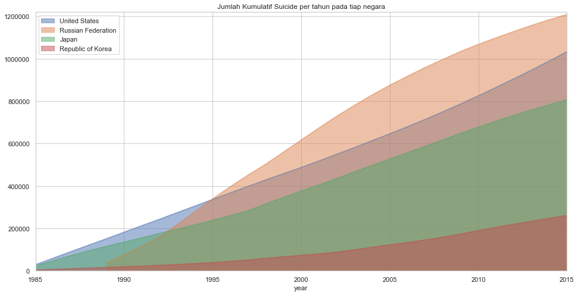

```python
def country_cumulative(all_country):
    fig, ax = plt.subplots(figsize=(16, 8))
    all_max = 0
    for country in all_country:
        data_country = data_all_year[data_all_year['country']== country]
        data_country['cum_sum'] = data_country['suicides_no'].cumsum()
        data_country.index = data_country.year
        country_max = data_country.cum_sum.max()
        if country_max > all_max:
            all_max = country_max
        ax = data_country.cum_sum.plot.area(stacked=False, label = country)

    ax.legend()
    ax.set_title('Jumlah Kumulatif Suicide per tahun pada tiap negara')
    plt.ylim(0, all_max+10000)

country_cumulative(['United States', 'Russian Federation','Japan','Republic of Korea'])
```